# Exercise 11.11

Kári Hlynsson

April 2024

This example make use of the data in Table 11.4.

## Part (a)

Create two groups of observations. In Group 1, $X < 2$, whereas in Group 2, $X \geq 2$. Plot the Kaplan-Meier survival curves corresponding to the two groups. Be sure to label the curves so that it is clear which curve corresponds to which group. By eye, does there appear to be a difference between the two groups’ survival curves?

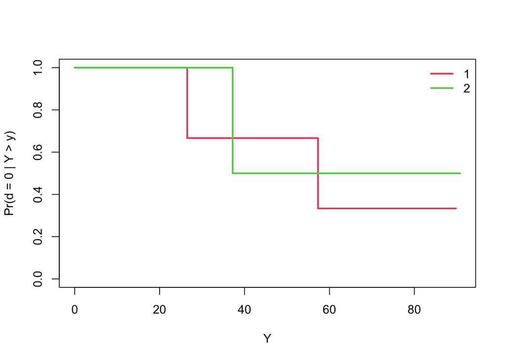

```r
library(survival)

dat <- data.frame(
  Y = c(26.5, 37.2, 57.3, 90.8, 20.2, 89.8),
  d = c(1, 1, 1, 0, 0, 0),
  X = c(0.1, 11, -0.3, 2.8, 1.8, 0.4)
)

dat$G <- as.factor(ifelse(dat$X < 2, "1", "2"))

attach(dat)

surv_fit <- survfit(Surv(Y, d) ~ G)
plot(surv_fit, lwd = 2.25, col = 2:3, xlab = "Y", ylab = "Pr(d = 0 | Y > y)")
legend("topright", bty = "n", legend = levels(G), lwd = 2.25, col = 2:3)
```

No discernible difference at first glance, or not one I would be comfortable standing by.

## Part (b)

Fit Cox’s proportional hazards model, using the group indicator as a covariate. What is the estimated coefficient? Write a sentence providing the interpretation of this coefficient, in terms of the hazard or the instantaneous probability of the event. Is there evidence that the true coefficient value is non-zero?

```r
cox_fit <- coxph(Surv(Y, d) ~ G)
summary(cox_fit)
```

```
## Call:
## coxph(formula = Surv(Y, d) ~ G)
##
##   n= 6, number of events= 3
##
##       coef exp(coef) se(coef)      z Pr(>|z|)
## G2 -0.3401    0.7117   1.2359 -0.275    0.783
##
##    exp(coef) exp(-coef) lower .95 upper .95
## G2    0.7117      1.405   0.06314     8.022
##
## Concordance= 0.556  (se = 0.169 )
## Likelihood ratio test= 0.08  on 1 df,   p=0.8
## Wald test            = 0.08  on 1 df,   p=0.8
## Score (logrank) test = 0.08  on 1 df,   p=0.8
```

Estimated coefficient shown in output above. The interpretation is that for an observation identical to another in every regard other than being G2 whereas its counterpart is G1, this would correspond to them being $exp(-0.3401) = 0.7117$ less likely to experience the event. However, the Wald test is not significant $p \approx 0.783$ and thus we can not sustain this claimin actuality.

## Part (c)

Recall from Section 11.5.2 that in the case of a single binary covariate, the log-rank test statistic should be identical to the score statistic for the Cox model. Conduct a log-rank test to deterine whether there is a difference between the survival curves for the two groups. How does the $p$-value for the log-rank test statistic compare to the previous $p$-value for the score statistic for the Cox model from (b)?

```r
summary(cox_fit)$sctest
```

```
##       test         df     pvalue
## 0.07644306 1.00000000 0.78217683
```

```r
survdiff(Surv(Y, d) ~ G)$pvalue
```

```
## [1] 0.7821768
```

$p$-values insignificant in both tests – no evidence for claiming that there is a difference in outcome between groups G1 and G2.